# Section 2.1

#### Question 2

**(a)**

Let S(t) represent the number of steps recorded t minutes after 3:00 PM. The slope of a secant line over an interval [a,b] is

$$ \frac{\Delta S}{\Delta t} = \frac{S(b)-S(a)}{b-a} $$

This slope represents the average walking rate in steps per minute.

(i) Interval [0,40]

$$ \frac{S(40)-S(0)}{40-0} = \frac{7398-3438}{40} = \frac{3960}{40} = \boxed{99 \text{ steps/min}} $$

(ii) Interval [10,20]

$$ \frac{S(20)-S(10)}{20-10} = \frac{5622-4559}{10} = \frac{1063}{10} = \boxed{106.3 \text{ steps/min}} $$

(iii) Interval [20,30]

$$ \frac{S(30)-S(20)}{30-20} = \frac{6536-5622}{10} = \frac{914}{10} = \boxed{91.4 \text{ steps/min}} $$

**b**

The number of steps is given as a function of time $t$, measured in minutes after 3:00 PM.

Since 3:20 PM is **20 minutes after 3:00 PM**, we estimate the student’s walking pace at $t = 20$ by averaging the slopes of two secant lines on either side of $t = 20$.

Secant slopes from part (a)

- On the interval $[10,20]$:

$$ \frac{5622 - 4559}{20 - 10} = \frac{1063}{10} = 106.3 \text{ steps/min} $$

- On the interval $[20,30]$:

$$ \frac{6536 - 5622}{30 - 20} = \frac{914}{10} = 91.4 \text{ steps/min} $$

Average of the two secant slopes

$$ \frac{106.3 + 91.4}{2} = 98.85 \text{ steps/min} $$

#### Question 5

Given the height function (in feet): $$ y(t) = 275 - 16t^2 $$

**(a)**

Average velocity over the interval $([4,\,4+\Delta t])$ is $$ v_{\text{avg}} = \frac{y(4+\Delta t) - y(4)}{\Delta t} $$

First compute: $$ y(4) = 275 - 16(4)^2 = 19 $$

i. $(\Delta t = 0.1)$ $$ y(4.1) = 275 - 16(4.1)^2 = 6.04 $$ $$ v_{\text{avg}} = \frac{6.04 - 19}{0.1} = \boxed{-129.6\ \text{ft/s}} $$

ii. $(\Delta t = 0.05)$ $$ y(4.05) = 275 - 16(4.05)^2 = 12.56 $$ $$ v_{\text{avg}} = \frac{12.56 - 19}{0.05} = \boxed{-128.8\ \text{ft/s}} $$

iii. $(\Delta t = 0.01)$ $$ y(4.01) = 275 - 16(4.01)^2 = 17.7184 $$ $$ v_{\text{avg}} = \frac{17.7184 - 19}{0.01} = \boxed{-128.16\ \text{ft/s}} $$

**(b)**

As $(\Delta t \to 0)$, the average velocities approach $$ \boxed{-128\ \text{ft/s}} $$

(The negative sign indicates downward motion.)

#### Question 7

**(a.)** Average velocity on an interval $[a,b]$ is $$ v_{\text{avg}}=\frac{s(b)-s(a)}{b-a}. $$

From the table (position in feet, time in seconds): $$ s(2)=20.6\ \text{ft},\quad s(3)=46.5\ \text{ft},\quad s(4)=79.2\ \text{ft},\quad s(5)=124.8\ \text{ft},\quad s(6)=176.7\ \text{ft}. $$

**(i.)** Interval $[2,4]$: $$ \begin{aligned} v_{\text{avg}}[2,4] &=\frac{s(4)-s(2)}{4-2}\\ &=\frac{79.2\ \text{ft}-20.6\ \text{ft}}{4\ \text{s}-2\ \text{s}}\\ &=\frac{58.6\ \text{ft}}{2\ \text{s}}\\ &=29.3\ \text{ft/s}. \end{aligned} $$ $$ \boxed{v_{\text{avg}}[2,4]=29.3\ \text{ft/s}} $$

**(ii.)** Interval $[3,4]$: $$ \begin{aligned} v_{\text{avg}}[3,4] &=\frac{s(4)-s(3)}{4-3}\\ &=\frac{79.2\ \text{ft}-46.5\ \text{ft}}{4\ \text{s}-3\ \text{s}}\\ &=\frac{32.7\ \text{ft}}{1\ \text{s}}\\ &=32.7\ \text{ft/s}. \end{aligned} $$ $$ \boxed{v_{\text{avg}}[3,4]=32.7\ \text{ft/s}} $$

**(iii.)** Interval $[4,5]$: $$ \begin{aligned} v_{\text{avg}}[4,5] &=\frac{s(5)-s(4)}{5-4}\\ &=\frac{124.8\ \text{ft}-79.2\ \text{ft}}{5\ \text{s}-4\ \text{s}}\\ &=\frac{45.6\ \text{ft}}{1\ \text{s}}\\ &=45.6\ \text{ft/s}. \end{aligned} $$ $$ \boxed{v_{\text{avg}}[4,5]=45.6\ \text{ft/s}} $$

**(iv.)** Interval $[4,6]$: $$ \begin{aligned} v_{\text{avg}}[4,6] &=\frac{s(6)-s(4)}{6-4}\\ &=\frac{176.7\ \text{ft}-79.2\ \text{ft}}{6\ \text{s}-4\ \text{s}}\\ &=\frac{97.5\ \text{ft}}{2\ \text{s}}\\ &=48.75\ \text{ft/s}. \end{aligned} $$ $$ \boxed{v_{\text{avg}}[4,6]=48.75\ \text{ft/s}} $$

**(b.)** Use the graph of $s$ as a function of $t$ to estimate the instantaneous velocity when $t=3$.

Use average velocities on intervals closest to $t=3$:

$$ \begin{aligned} v_{\text{avg}}[2,3] &=\frac{s(3)-s(2)}{3-2}\\ &=\frac{46.5\ \text{ft}-20.6\ \text{ft}}{3\ \text{s}-2\ \text{s}}\\ &=\frac{25.9\ \text{ft}}{1\ \text{s}}\\ &=25.9\ \text{ft/s}, \\[6pt] v_{\text{avg}}[3,4] &=\frac{s(4)-s(3)}{4-3}\\ &=\frac{79.2\ \text{ft}-46.5\ \text{ft}}{4\ \text{s}-3\ \text{s}}\\ &=\frac{32.7\ \text{ft}}{1\ \text{s}}\\ &=32.7\ \text{ft/s}. \end{aligned} $$

A reasonable estimate for the instantaneous velocity at $t=3$ is the midpoint of these nearby slopes: $$ v(3)\approx \frac{25.9+32.7}{2}\ \text{ft/s} =29.3\ \text{ft/s}. $$ $$ \boxed{v(3)\approx 29.3\ \text{ft/s}} $$

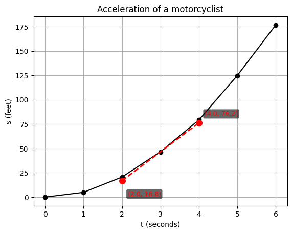

**(b.)** Use the graph of $s$ as a function of $t$ to estimate the instantaneous velocity when $t=3$.

To estimate the instantaneous velocity at $t=3$, we consider the slope of the tangent line to the graph of $s(t)$ at $t=3$. Using the graph of the data points $$ t=[0,1,2,3,4,5,6], \quad s=[0,4.9,20.6,46.5,79.2,124.8,176.7], $$ a tangent line drawn at the point $(3,46.5)$ has slope approximately $29.7$.

Thus, the instantaneous velocity at $t=3$ is estimated to be $$ \boxed{v(3)\approx 29.7\ \text{ft/s}}. $$

# Section 2.2

#### Question 6

**(a.)** Left-hand limit $$ \boxed{\lim_{x \to -3^-} h(x) = 4} $$ **Exists:** Yes.

**(b.)** Right-hand limit $$ \boxed{\lim_{x \to -3^+} h(x) = 4} $$ **Exists:** Yes.

**(c.)** Two-sided limit $$ \boxed{\lim_{x \to -3} h(x) = 4} $$ **Exists:** Yes.

**(d.)** Function value $$ \boxed{h(-3)\text{ DNE}} $$ **Exists:** No.

**Reason:** There is no filled point at $x=-3$.

**(e.)** Left-hand limit $$ \boxed{\lim_{x \to 0^-} h(x) = 1} $$ **Exists:** Yes.

**(f.)** Right-hand limit $$ \boxed{\lim_{x \to 0^+} h(x) = -1} $$ **Exists:** Yes.

**(g.)** Two-sided limit $$ \boxed{\lim_{x \to 0} h(x)\text{ DNE}} $$ **Exists:** No.

**Reason:** The left-hand limit and right-hand limit are not equal.

**(h.)** Function value $$ \boxed{h(0) = 1} $$ **Exists:** Yes.

**(i.)** Two-sided limit $$ \boxed{\lim_{x \to 2} h(x) = 2} $$ **Exists:** Yes.

**(j.)** Function value $$ \boxed{h(2)\text{ DNE}} $$ **Exists:** No.

**Reason:** There is an open circle at $x=2$ and no filled point.

**(k.)** Right-hand limit $$ \boxed{\lim_{x \to 5^+} h(x) = 3} $$ **Exists:** Yes.

**(l.)** Left-hand limit $$ \boxed{\lim_{x \to 5^-} h(x)\text{ DNE}} $$ **Exists:** No.

**Reason:** As $x$ approaches $5$ from the left, $h(x)$ oscillates between approximately $2$ and $4$ and does not approach a single value.

#### Question 10

A patient receives a 150-mg injection of a drug every 4 hours. The graph shows the amount $f(t)$ of the drug in the bloodstream after $t$ hours.

Left-hand limit

$$ \lim_{t \to 12^-} f(t) $$

$$ \boxed{150} $$

Right-hand limit

$$ \lim_{t \to 12^+} f(t) $$

$$ \boxed{300} $$

Interpretation

- $\lim_{t \to 12^-} f(t)$ is the amount of drug just before the injection at $t=12$.
- $\lim_{t \to 12^+} f(t)$ is the amount of drug immediately after the injection at $t=12$.

#### Question 11

$\displaystyle f(x)= \begin{cases} e^x, & x \le 0,\\ x-1, & 0 < x < 1,\\ \ln(x), & x \ge 1 \end{cases} $

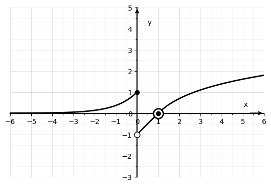

Given the piecewise function we determine the values of $a$ for which $\lim_{x \to a} f(x)$ exists.

Each expression defining $f$ is continuous on its interval. Therefore, $\lim_{x \to a} f(x)$ exists for all $a$ in the interior of each interval. The limit can fail to exist only at the transition points $x=0$ and $x=1$.

**At $x=0$:** $$ \lim_{x \to 0^-} f(x)=e^0=1, \qquad \lim_{x \to 0^+} f(x)=0-1=-1 $$ Since the one-sided limits are not equal, $\lim_{x \to 0} f(x)$ does not exist.

**At $x=1$:** $$ \lim_{x \to 1^-} f(x)=1-1=0, \qquad \lim_{x \to 1^+} f(x)=\ln(1)=0 $$ Since the one-sided limits are equal, $\lim_{x \to 1} f(x)$ exists.

$$ \boxed{\lim_{x \to a} f(x)\ \text{exists for all } a \neq 0} $$

#### Question 19

Numerical evaluation near $x=3$

Let $$ f(x)=\frac{x^2-3x}{x^2-9}, \quad x\neq 3. $$

Evaluate the function at values close to $3$, rounding to six decimal places.

$$ f(3.1)=\frac{(3.1)^2-3(3.1)}{(3.1)^2-9} =\frac{9.61-9.3}{9.61-9} =\boxed{0.508197} $$

$$ f(3.05)=\frac{(3.05)^2-3(3.05)}{(3.05)^2-9} =\frac{9.3025-9.15}{9.3025-9} =\boxed{0.504132} $$

$$ f(3.01)=\frac{(3.01)^2-3(3.01)}{(3.01)^2-9} =\frac{9.0601-9.03}{9.0601-9} =\boxed{0.500832} $$

$$ f(3.001)=\frac{(3.001)^2-3(3.001)}{(3.001)^2-9} =\frac{9.006001-9.003}{9.006001-9} =\boxed{0.500083} $$

$$ f(3.0001)=\frac{(3.0001)^2-3(3.0001)}{(3.0001)^2-9} =\frac{9.00060001-9.0003}{9.00060001-9} =\boxed{0.500008} $$

$$ f(2.9)=\frac{(2.9)^2-3(2.9)}{(2.9)^2-9} =\frac{8.41-8.7}{8.41-9} =\boxed{0.491525} $$

$$ f(2.95)=\frac{(2.95)^2-3(2.95)}{(2.95)^2-9} =\frac{8.7025-8.85}{8.7025-9} =\boxed{0.495798} $$

$$ f(2.99)=\frac{(2.99)^2-3(2.99)}{(2.99)^2-9} =\frac{8.9401-8.97}{8.9401-9} =\boxed{0.499165} $$

$$ f(2.999)=\frac{(2.999)^2-3(2.999)}{(2.999)^2-9} =\frac{8.994001-8.997}{8.994001-9} =\boxed{0.499917} $$

From both the left and the right, the function values approach $0.5$.

$$ \boxed{\frac{1}{2}} $$

#### Question 32

$$ \lim_{x\to 3^-} \frac{\sqrt{x}}{(x-3)^5} $$

- As $x\to 3^-$, $\sqrt{x}\to \sqrt{3}$ (finite and positive)
- $(x-3)^5 \to 0^-$ (odd power preserves sign)

Thus the quotient decreases without bound.

$$ \boxed{-\infty} $$

#### Question 38

$$ \lim_{x\to 3^-} \frac{x^2+4x}{x^2-2x-3} $$

Factor: $$ \frac{x(x+4)}{(x-3)(x+1)} $$

Sign analysis as $x\to 3^-$:

- Numerator $>0$
- Denominator $<0$

Therefore the expression decreases without bound.

$$ \boxed{-\infty} $$

#### Question 40

$$ \lim_{x\to 0^+} \left(\frac{1}{x}-\ln x\right) $$

As $x\to 0^+$: $$ \frac{1}{x}\to +\infty, \qquad \ln x\to -\infty $$

Thus $$ \frac{1}{x}-\ln x \to +\infty $$

$$ \boxed{+\infty} $$

# Section 2.3

#### Question 6

Evaluate the limit: $$ \lim_{t \to 7}\frac{3t^2+1}{t^2-5t+2} $$

By the **Quotient Law**, provided the denominator limit is nonzero, $$ \lim_{t \to 7}\frac{3t^2+1}{t^2-5t+2} = \frac{\lim_{t \to 7}(3t^2+1)}{\lim_{t \to 7}(t^2-5t+2)} $$

Numerator

Using the **Sum Law** and **Constant Multiple Law**, $$ \lim_{t \to 7}(3t^2+1) = \lim_{t \to 7}(3t^2)+\lim_{t \to 7}(1) = 3\lim_{t \to 7}(t^2)+1 $$

Using the **Power of $x$ Law** and **Constant Law**, $$ =3(7^2)+1=148 $$

Denominator

Using the **Difference Law**, **Sum Law**, and **Constant Multiple Law**, $$ \lim_{t \to 7}(t^2-5t+2) = \lim_{t \to 7}(t^2)-\lim_{t \to 7}(5t)+\lim_{t \to 7}(2) $$

Using the **Power of $x$ Law**, **Identity Law**, and **Constant Law**, $$ =7^2-5(7)+2=16 $$

Validity of the Quotient Law

Since $$ \lim_{t \to 7}(t^2-5t+2)=16\neq 0, $$ the Quotient Law applies

$$ \boxed{\frac{37}{4}} $$

#### Question 10

**(a.)** What is wrong with the equation $$ \frac{x^2+x-6}{x-2}=x+3 \, ? $$

Factor the numerator: $$ x^2+x-6=(x+3)(x-2) $$ So for $x\neq 2$, $$ \frac{x^2+x-6}{x-2}=\frac{(x+3)(x-2)}{x-2}=x+3 $$ But at $x=2$ the left-hand side is **undefined** (division by $0$), while $x+3$ **is** defined. So the equation is not true “for all $x$”; it is only true for $x\neq 2$.

$$ \boxed{\text{The left side is undefined at }x=2,\text{ so it cannot equal }x+3\text{ there.}} $$

**(b.)** Explain why $$ \lim_{x\to 2}\frac{x^2+x-6}{x-2}=\lim_{x\to 2}(x+3) $$ is correct.

Because the two functions are equal for all $x$ sufficiently close to $2$ (except at $x=2$ itself): $$ \frac{x^2+x-6}{x-2}=x+3 \quad \text{for }x\neq 2 $$ $$ \boxed{\text{Limits only depend on values near the point, not at the point, so the limits agree.}} $$ $$ \lim_{x\to 2}\frac{x^2+x-6}{x-2} =\lim_{x\to 2}(x+3)=5 $$

#### Question 16

Evaluate (if it exists): $$ \lim_{x\to 4}\frac{x^2+3x}{x^2-x-12} $$

Factor $$ \frac{x^2+3x}{x^2-x-12} = \frac{x(x+3)}{(x-4)(x+3)} $$

Cancel the common factor $(x+3)$ (valid when $x\neq -3$) $$ \frac{x(x+3)}{(x-4)(x+3)} = \frac{x}{x-4} \quad (x\neq -3) $$

Now check one-sided behavior as $x\to 4$

**(a.)** Left-hand limit $$ \lim_{x\to 4^-}\frac{x^2+3x}{x^2-x-12} = \lim_{x\to 4^-}\frac{x}{x-4} $$

As $x\to 4^-$, we have $x\approx 4>0$ and $x-4<0$, so $\frac{x}{x-4}\to -\infty$

$$ \lim_{x\to 4^-}\frac{x^2+3x}{x^2-x-12}=-\infty $$

**(b.)** Right-hand limit $$ \lim_{x\to 4^+}\frac{x^2+3x}{x^2-x-12} = \lim_{x\to 4^+}\frac{x}{x-4} $$

As $x\to 4^+$, we have $x\approx 4>0$ and $x-4>0$, so $\frac{x}{x-4}\to +\infty$

$$ \lim_{x\to 4^+}\frac{x^2+3x}{x^2-x-12}=+\infty $$

Since the one-sided limits are not equal, the two-sided limit does not exist $$ \boxed{\lim_{x\to 4}\frac{x^2+3x}{x^2-x-12}\ \text{DNE}} $$

#### Question 18

Evaluate (if it exists): $$ \lim_{x\to -5}\frac{2x^2+9x-5}{x^2-25} $$

Factor $$ 2x^2+9x-5=(2x-1)(x+5), \qquad x^2-25=(x-5)(x+5) $$

Cancel $(x+5)$ (valid when $x\neq -5$) $$ \frac{2x^2+9x-5}{x^2-25} = \frac{(2x-1)(x+5)}{(x-5)(x+5)} = \frac{2x-1}{x-5} $$

Now substitute $x=-5$ $$ \lim_{x\to -5}\frac{2x-1}{x-5} = \frac{2(-5)-1}{-5-5} = \frac{-11}{-10} = \frac{11}{10} $$

Therefore the limit exists $$ \boxed{\frac{11}{10}} $$

#### Question 19

Evaluate (if it exists): $$ \lim_{t\to 3}\frac{t^3-27}{t^2-9} $$

Factor $$ t^3-27=(t-3)(t^2+3t+9), \qquad t^2-9=(t-3)(t+3) $$

Cancel $(t-3)$ (valid when $t\neq 3$) $$ \frac{t^3-27}{t^2-9} = \frac{(t-3)(t^2+3t+9)}{(t-3)(t+3)} = \frac{t^2+3t+9}{t+3} $$

Now substitute $t=3$ $$ \lim_{t\to 3}\frac{t^2+3t+9}{t+3} = \frac{9+9+9}{6} = \frac{27}{6} = \frac{9}{2} $$

Therefore the limit exists $$ \boxed{\frac{9}{2}} $$

#### Question 26

Evaluate (if it exists): $$ \lim_{h\to 0}\frac{\dfrac{1}{-2+h}-\dfrac{1}{-2}}{h} $$

Rewrite the numerator $$ \frac{1}{-2+h}-\frac{1}{-2} = \frac{1}{-2+h}+\frac12 $$

Combine the fractions $$ \frac{1}{-2+h}+\frac12 = \frac{2+(-2+h)}{2(-2+h)} = \frac{h}{2(-2+h)} $$

Divide by $h$ $$ \frac{\dfrac{h}{2(-2+h)}}{h} = \frac{1}{2(-2+h)} $$

Take the limit by direct substitution $$ \lim_{h\to 0}\frac{1}{2(-2+h)} = \frac{1}{2(-2)} = -\frac14 $$

Therefore the limit exists $$ \boxed{-\frac14} $$

#### Question 30

Evaluate (if it exists): $$ \lim_{x\to 2}\frac{x^2-4x+4}{x^4-3x^2-4} $$

Factor the numerator $$ x^2-4x+4=(x-2)^2 $$

Factor the denominator $$ x^4-3x^2-4 = (x^2-4)(x^2+1) = (x-2)(x+2)(x^2+1) $$

Cancel one factor of $(x-2)$ (valid when $x\neq 2$) $$ \frac{(x-2)^2}{(x-2)(x+2)(x^2+1)} = \frac{x-2}{(x+2)(x^2+1)} $$

Take the limit by direct substitution $$ \lim_{x\to 2}\frac{x-2}{(x+2)(x^2+1)} = \frac{2-2}{(2+2)(2^2+1)} = \frac{0}{(4)(5)} = 0 $$

Therefore the limit exists $$ \boxed{0} $$

#### Question 38

Evaluate: $$ \lim_{x\to 0}\sqrt{x^3+x^2\sin\!\left(\frac{\pi}{x}\right)} $$

For all $x\neq 0$, we know $$ -1\le \sin\!\left(\frac{\pi}{x}\right)\le 1 \quad\Rightarrow\quad x^2\sin\!\left(\frac{\pi}{x}\right)\le x^2 \ \ (\text{since }x^2\ge 0) $$ So $$ x^3+x^2\sin\!\left(\frac{\pi}{x}\right)\le x^3+x^2=x^2(x+1) $$

Whenever the square-root expression is defined (i.e., the inside is $\ge 0$), we have: $$ 0\le \sqrt{x^3+x^2\sin\!\left(\frac{\pi}{x}\right)} \le \sqrt{x^2(x+1)}=|x|\sqrt{x+1} $$ As $x\to 0$, $|x|\sqrt{x+1}\to 0$. By the Squeeze Theorem, $$ \lim_{x\to 0}\sqrt{x^3+x^2\sin\!\left(\frac{\pi}{x}\right)}=0 $$

$$ \boxed{0} $$

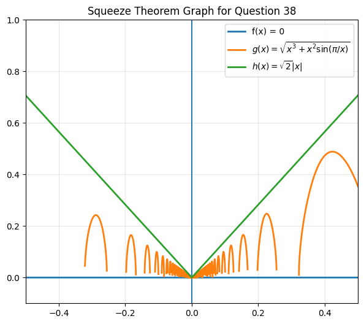

# Section 2.4

#### Question 2

We want a number $\delta>0$ such that if $0<|x-3|<\delta$, then $|f(x)-2|<0.5$

The condition $|f(x)-2|<0.5$ means $$ 1.5<f(x)<2.5 $$

From the graph, the horizontal lines $y=1.5$ and $y=2.5$ intersect the curve at approximately $$ x=2.6 \quad\text{and}\quad x=3.8 $$

So we need $(3-\delta,\,3+\delta)\subset (2.6,\,3.8)$

The largest allowable $\delta$ is the smaller distance to the endpoints $$ \delta=\min\{3-2.6,\;3.8-3\}=\min\{0.4,\;0.8\}=0.4 $$

$$ \boxed{\delta=0.4} $$

#### Question 14

Given that $$ \lim_{x\to 2}(5x-7)=3 $$ find values of $\delta$ corresponding to $\varepsilon=0.1,\;0.05,\;0.01$

Start from the $\varepsilon$-condition $$ |(5x-7)-3|<\varepsilon $$

Simplify $$ |(5x-7)-3|=|5x-10|=5|x-2| $$

So it is enough to require $$ 5|x-2|<\varepsilon \quad\Longrightarrow\quad |x-2|<\frac{\varepsilon}{5} $$

$$ \boxed{\delta=\frac{\varepsilon}{5}} $$

Now plug in the requested $\varepsilon$ values

- If $\varepsilon=0.1$, then $\delta=\dfrac{0.1}{5}=0.02$, so $$ \boxed{\delta=0.02} $$
- If $\varepsilon=0.05$, then $\delta=\dfrac{0.05}{5}=0.01$, so $$ \boxed{\delta=0.01} $$
- If $\varepsilon=0.01$, then $\delta=\dfrac{0.01}{5}=0.002$, so $$ \boxed{\delta=0.002} $$

#### Question 16

Prove using the $\varepsilon$-$\delta$ definition that $$ \lim_{x\to 2}(2-3x)=-4 $$

Let $\varepsilon>0$ be given

We want $\delta>0$ such that if $0<|x-2|<\delta$, then $$ |(2-3x)-(-4)|<\varepsilon $$

Simplify the left-hand side $$ |(2-3x)+4|=|6-3x|=|{-3}(x-2)|=3|x-2| $$

So it is enough to require $$ 3|x-2|<\varepsilon \quad\Longrightarrow\quad |x-2|<\frac{\varepsilon}{3} $$

$$ \boxed{\delta=\frac{\varepsilon}{3}} $$

Then $0<|x-2|<\delta$ implies $|(2-3x)-(-4)|=3|x-2|<3\delta=\varepsilon$, as required

#### Question 17

Prove using the $\varepsilon$-$\delta$ definition that $$ \lim_{x\to -2}(-2x+1)=5 $$

Let $\varepsilon>0$ be given

We want $\delta>0$ such that if $0<|x-(-2)|=|x+2|<\delta$, then $$ |(-2x+1)-5|<\varepsilon $$

Simplify $$ |(-2x+1)-5| = |-2x-4| = |{-2}(x+2)| = 2|x+2| $$

So it is enough to require $$ 2|x+2|<\varepsilon \quad\Longrightarrow\quad |x+2|<\frac{\varepsilon}{2} $$

$$ \boxed{\delta=\frac{\varepsilon}{2}} $$

Then $0<|x+2|<\delta$ implies $|(-2x+1)-5|=2|x+2|<2\delta=\varepsilon$, as required

# Section 2.5

#### Question 7

Sketch the graph of a function $f$ that is defined on $\mathbb{R}$ and continuous except for:

- a **removable discontinuity** at $x=-2$
- an **infinite discontinuity** at $x=2$

[figure not shown]

#### Question 20

The function is defined by $$ f(x)= \begin{cases} \dfrac{1}{x+2}, & x\neq -2,\\[6pt] 1, & x=-2 \end{cases} $$ with $a=-2$

Evaluate continuity at $x=-2$

**Two-sided limit** $$ \lim_{x\to -2} f(x)=\lim_{x\to -2}\frac{1}{x+2} $$

As $x\to -2^-$, we have $x+2<0$, so $$ \lim_{x\to -2^-}\frac{1}{x+2}=-\infty $$

As $x\to -2^+$, we have $x+2>0$, so $$ \lim_{x\to -2^+}\frac{1}{x+2}=+\infty $$

Since the one-sided limits are not equal, the two-sided limit does not exist

Because the limit does not exist, it cannot equal $f(-2)=1$

Therefore the function is discontinuous at $x=-2$

$$ \boxed{\text{Discontinuous at } x=-2} $$

$\displaystyle f(x)=\frac{1}{x+2}\ \text{for}\ x\ne -2,\quad f(-2)=1$

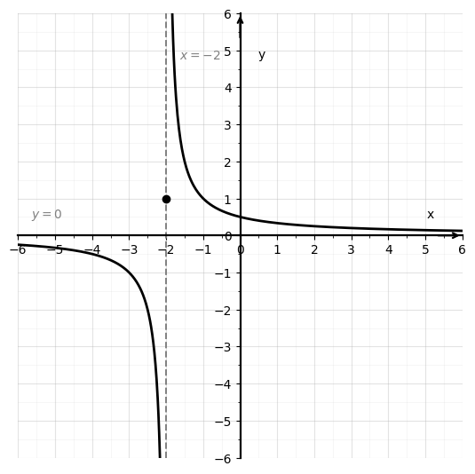

#### Question 24

The function is defined by $$ f(x)= \begin{cases} \dfrac{2x^2-5x-3}{x-3}, & x\neq 3,\\[6pt] 6, & x=3, \end{cases} $$ with $a=3$

Factor the numerator: $$ 2x^2-5x-3=(2x+1)(x-3) $$

For $x\neq 3$ $$ f(x)=2x+1 $$

**Two-sided limit** $$ \lim_{x\to 3} f(x)=\lim_{x\to 3}(2x+1)=7 $$

But $$ f(3)=6 $$

Since $$ \lim_{x\to 3} f(x)\neq f(3) $$ the function is discontinuous at $x=3$

$$ \boxed{\text{Removable discontinuity at } x=3} $$

$\displaystyle f(x)=\begin{cases}\dfrac{2x^2-5x-3}{x-3}, & x\neq 3\\[4pt]6, & x=3\end{cases}$

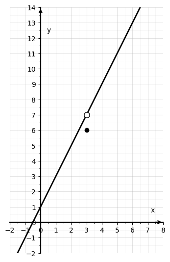

#### Question 45

The function is defined by $$ f(x)= \begin{cases} x+2, & x<0,\\ e^x, & 0\le x\le 1,\\ 2-x, & x>1 \end{cases} $$

Check continuity at the junction points

**At $x=0$**

Left-hand limit $$ \lim_{x\to 0^-} f(x)=\lim_{x\to 0^-}(x+2)=2 $$

Right-hand limit $$ \lim_{x\to 0^+} f(x)=\lim_{x\to 0^+}e^x=e^0=1 $$

Since $$ \lim_{x\to 0^-} f(x)\ne \lim_{x\to 0^+} f(x) $$ the two-sided limit $\lim_{x\to 0} f(x)$ does not exist

Also $$ f(0)=e^0=1 $$

$$ \boxed{\text{Discontinuous at } x=0} $$

**At $x=1$**

Left-hand limit $$ \lim_{x\to 1^-} f(x)=\lim_{x\to 1^-}e^x=e $$

Right-hand limit $$ \lim_{x\to 1^+} f(x)=\lim_{x\to 1^+}(2-x)=1 $$

Since $$ \lim_{x\to 1^-} f(x)\ne \lim_{x\to 1^+} f(x) $$ the two-sided limit $\lim_{x\to 1} f(x)$ does not exist

Also $$ f(1)=e^1=e $$

$$ \boxed{\text{Discontinuous at } x=1} $$

$\displaystyle f(x)= \begin{cases} x+2, & x<0,\\ e^x, & 0\le x\le 1,\\ 2-x, & x>1 \end{cases} $

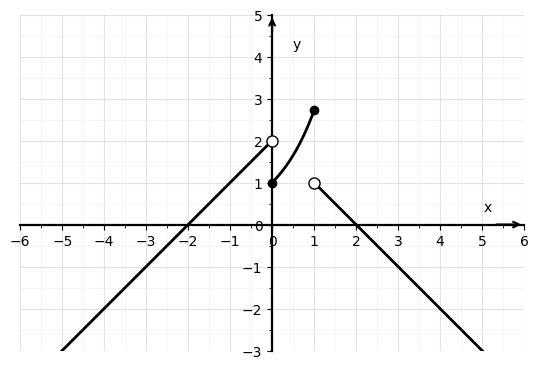